# HDT3Arboles

Ayleen Rubio 19003, Andrés Say 19705. Andreé Toledo 18439

8/3/2021

# Hoja de Trabajo No. 3: Árboles de Decisión

## Análisis Exploratorio

A continuación se mostrará un resumen de cada una de las variables y el tipo

```
##        Id           MSSubClass      MSZoning          LotFrontage
##  Min.   :   1.0   Min.   : 20.0   Length:1460        Min.   : 21.00
##  1st Qu.: 365.8   1st Qu.: 20.0   Class :character   1st Qu.: 59.00
##  Median : 730.5   Median : 50.0   Mode  :character   Median : 69.00
##  Mean   : 730.5   Mean   : 56.9                      Mean   : 70.05
##  3rd Qu.:1095.2   3rd Qu.: 70.0                      3rd Qu.: 80.00
##  Max.   :1460.0   Max.   :190.0                      Max.   :313.00
##                                                      NA's   :259
##     LotArea          Street             Alley             LotShape
##  Min.   :  1300   Length:1460        Length:1460        Length:1460
##  1st Qu.:  7554   Class :character   Class :character   Class :character
##  Median :  9478   Mode  :character   Mode  :character   Mode  :character
##  Mean   : 10517
##  3rd Qu.: 11602
##  Max.   :215245
##
##  LandContour         Utilities          LotConfig          LandSlope
##  Length:1460        Length:1460        Length:1460        Length:1460
##  Class :character   Class :character   Class :character   Class :character
##  Mode  :character   Mode  :character   Mode  :character   Mode  :character
##
##
##
##
##  Neighborhood        Condition1         Condition2          BldgType
##  Length:1460        Length:1460        Length:1460        Length:1460
##  Class :character   Class :character   Class :character   Class :character
##  Mode  :character   Mode  :character   Mode  :character   Mode  :character
##
##
##
##
##   HouseStyle         OverallQual      OverallCond      YearBuilt
##  Length:1460        Min.   : 1.000   Min.   :1.000   Min.   :1872
##  Class :character   1st Qu.: 5.000   1st Qu.:5.000   1st Qu.:1954
##  Mode  :character   Median : 6.000   Median :5.000   Median :1973
##                     Mean   : 6.099   Mean   :5.575   Mean   :1971
##                     3rd Qu.: 7.000   3rd Qu.:6.000   3rd Qu.:2000
##                     Max.   :10.000   Max.   :9.000   Max.   :2010
##
```

[output cut: 113 more lines]

```
##  Min.   : 1.000   Min.   :2006   Length:1460        Length:1460
##  1st Qu.: 5.000   1st Qu.:2007   Class :character   Class :character
##  Median : 6.000   Median :2008   Mode  :character   Mode  :character
##  Mean   : 6.322   Mean   :2008
##  3rd Qu.: 8.000   3rd Qu.:2009
##  Max.   :12.000   Max.   :2010
##
##    SalePrice
##  Min.   : 34900
##  1st Qu.:129975
##  Median :163000
##  Mean   :180921
##  3rd Qu.:214000
##  Max.   :755000
##
```

```
## 'data.frame':    1460 obs. of  81 variables:
##  $ Id           : int  1 2 3 4 5 6 7 8 9 10 ...
##  $ MSSubClass   : int  60 20 60 70 60 50 20 60 50 190 ...
##  $ MSZoning     : chr  "RL" "RL" "RL" "RL" ...
##  $ LotFrontage  : int  65 80 68 60 84 85 75 NA 51 50 ...
##  $ LotArea      : int  8450 9600 11250 9550 14260 14115 10084 10382 6120 7420 ...
##  $ Street       : chr  "Pave" "Pave" "Pave" "Pave" ...
##  $ Alley        : chr  NA NA NA NA ...
##  $ LotShape     : chr  "Reg" "Reg" "IR1" "IR1" ...
##  $ LandContour  : chr  "Lvl" "Lvl" "Lvl" "Lvl" ...
##  $ Utilities    : chr  "AllPub" "AllPub" "AllPub" "AllPub" ...
##  $ LotConfig    : chr  "Inside" "FR2" "Inside" "Corner" ...
##  $ LandSlope    : chr  "Gtl" "Gtl" "Gtl" "Gtl" ...
##  $ Neighborhood : chr  "CollgCr" "Veenker" "CollgCr" "Crawfor" ...
##  $ Condition1   : chr  "Norm" "Feedr" "Norm" "Norm" ...
```

[output cut: 67 more lines]

```
##
## character   integer
##        43        38
```

Con esto puede observarse que, del total de variables con las que cuenta nuestra base de datos, 43 son de tipo character y 38 son de tipo integer, siendo una de ellas el id por lo que no será utilizado en el futuro para formar grupos.

De estas variables se ha considerado que algunas de ellas valen la pena estudiarlas más a fondo para conocer las condiciones de los datos con los que se llevará a cabo el entrenamiento y las pruebas.

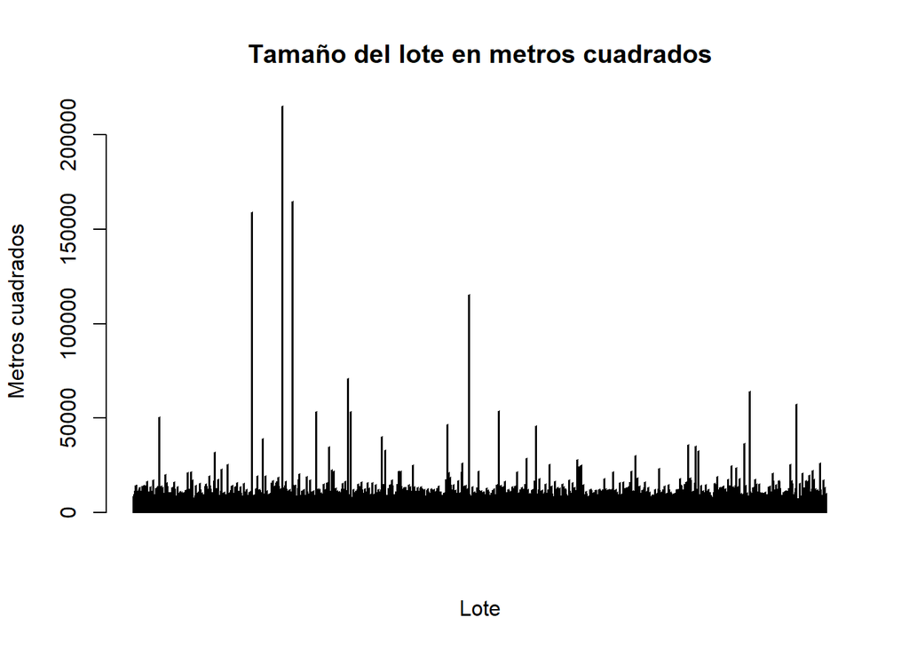

En este caso, puede observarse que la mayoría de casas se encuentra debajo de los 50,ooo metros cuadrados y que la casa que cuenta con mayor área de lote cuenta con más de 200,000 metros cuadrados.

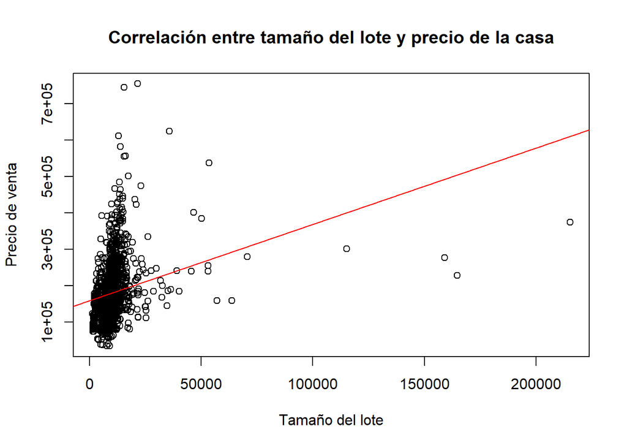

Puede observarse que no existe correlación entre el precio de la casa y el tamaño del lote, esto ya que la mayoría de valores se encuentran antes de los 50,000 metros cuadrados y el precio de venta cambia alrededor de los mismos tamaños de lote, además, las casas a mayor precio se encuentran entre los tamaño de lote menores.

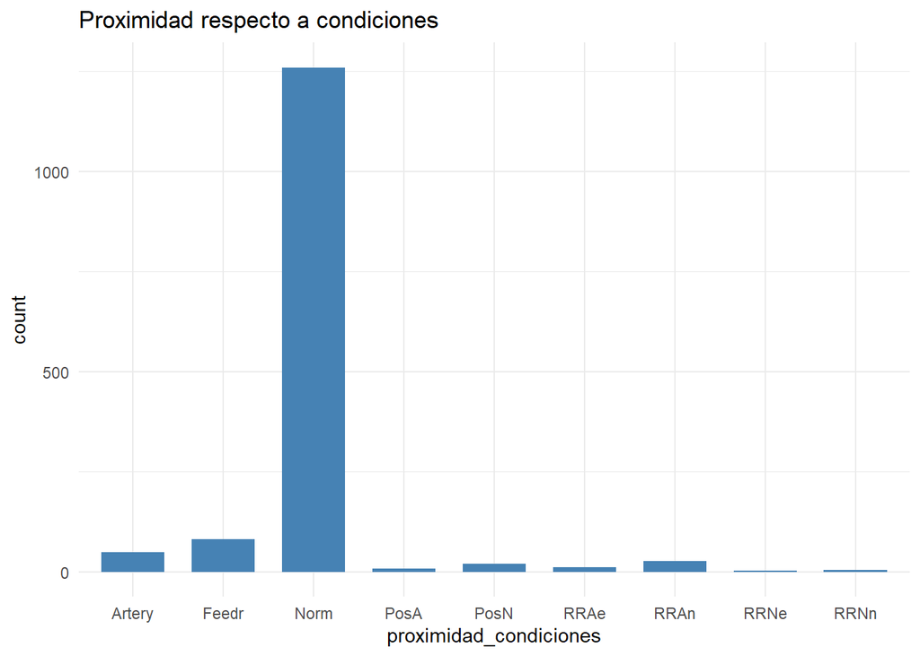

Puede observarse que la proximidad más común es la normal.

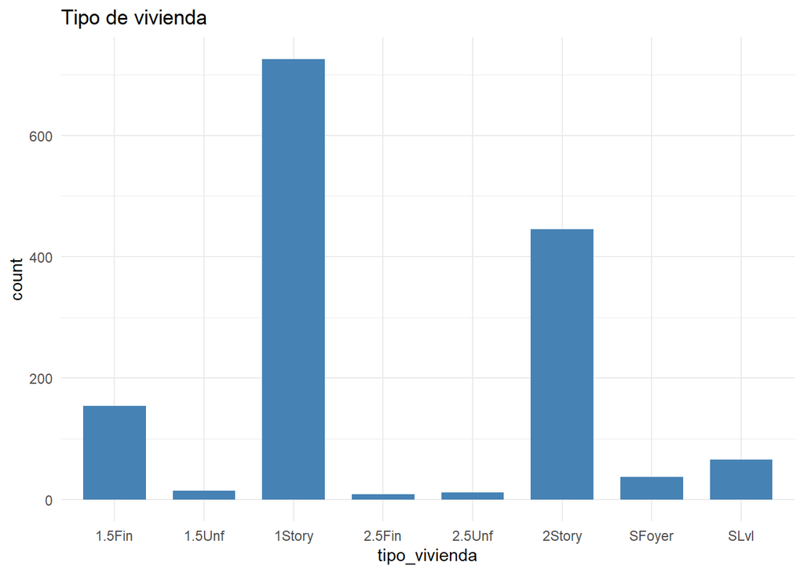

Puede observarse cómo es que el tipo de vivienda más común es el de un solo nivel, seguido por las casas de 2 niveles.

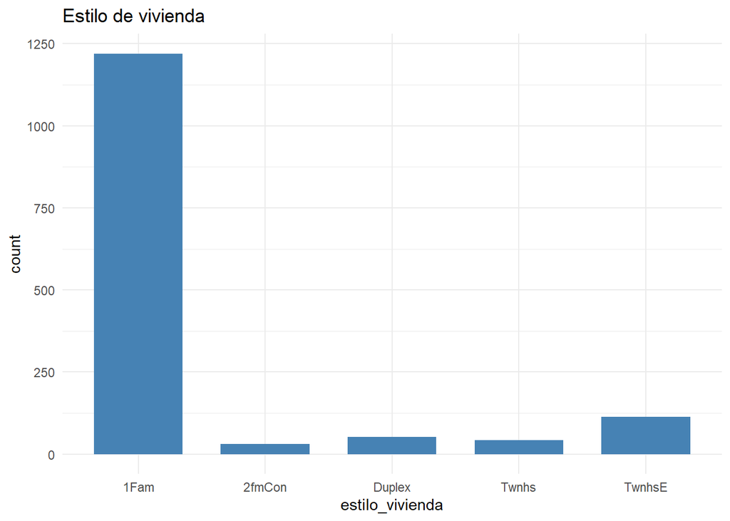

De la misma manera, puede observarse que los estilos de viviendas más comunes son para una sola familia.

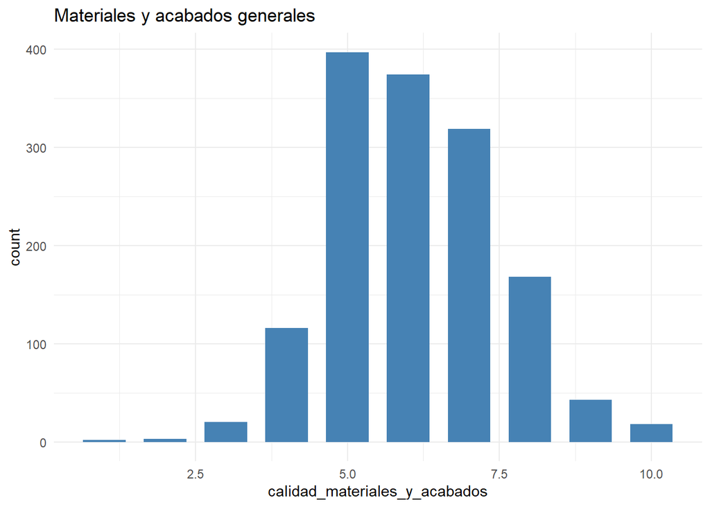

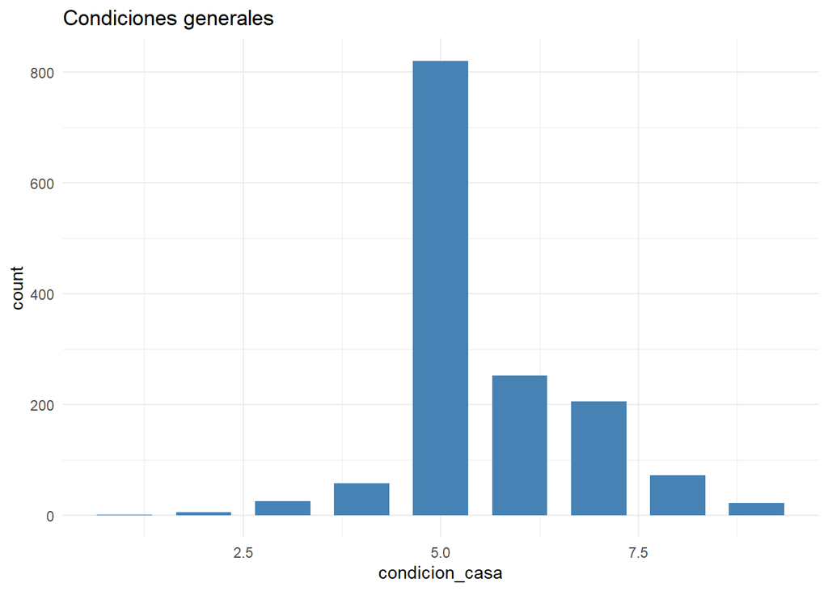

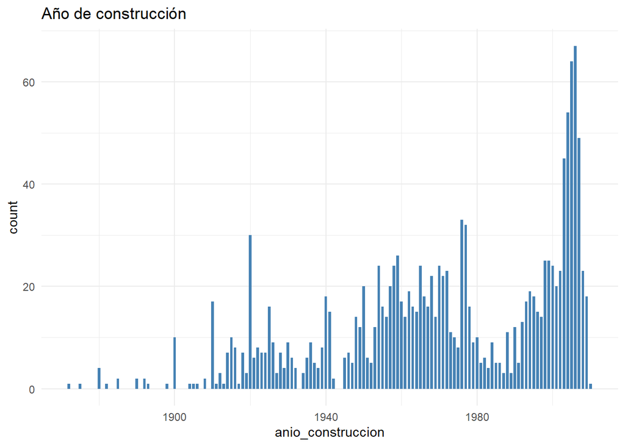

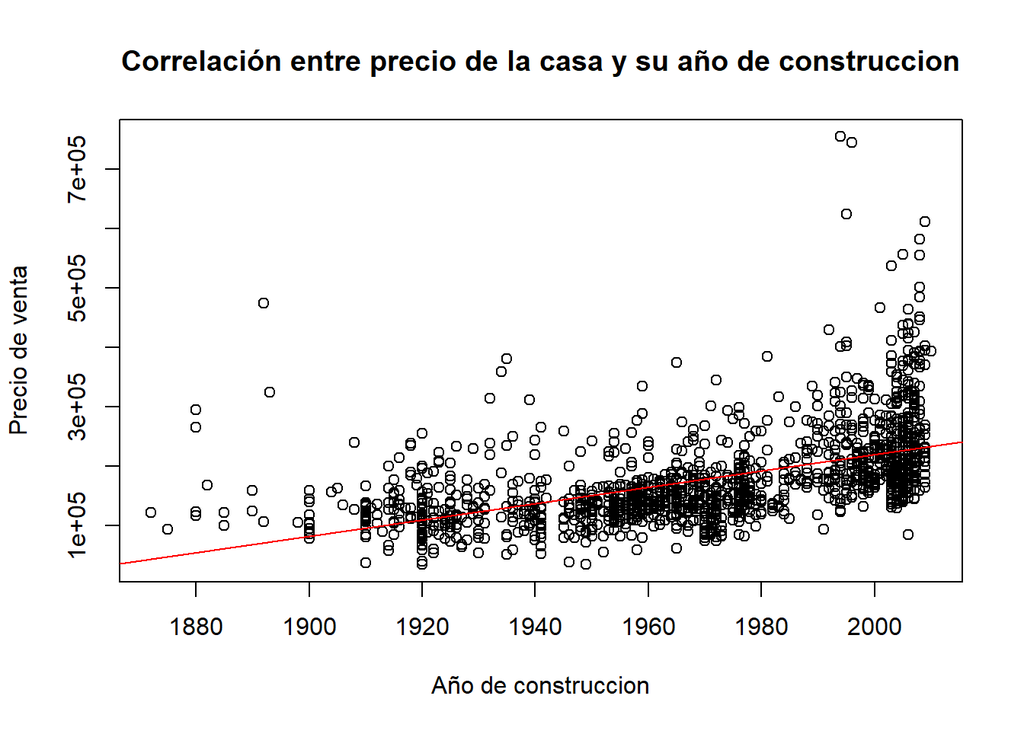

Como puede observarse, sí existe una correlación entre el año de construcción y el precio de la casa, ya que puede observarse cómo es que los valores de precio van aumentando a medida que los años van incrementando.

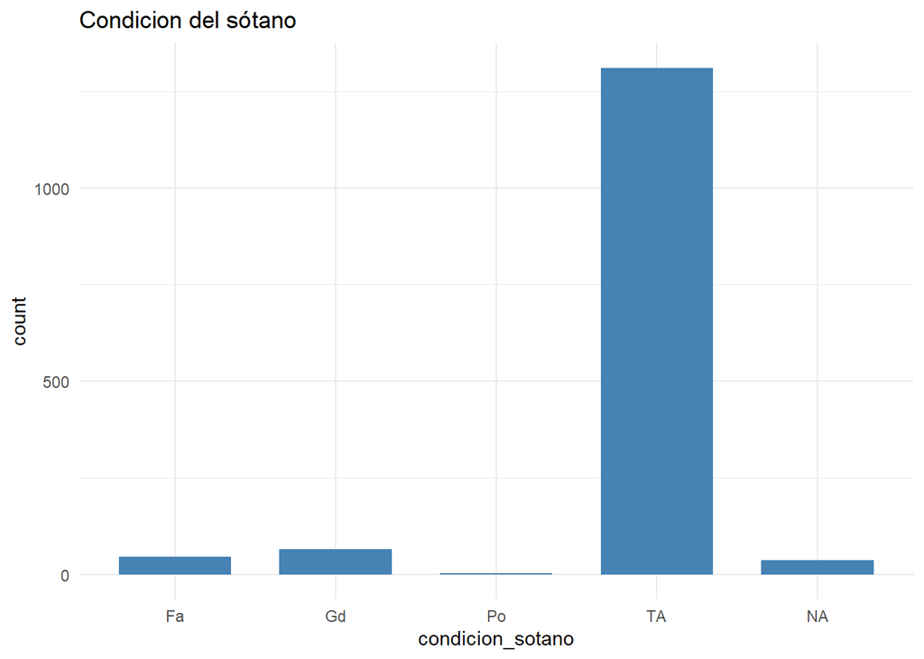

Podemos observar que la mayoría de los sótanos se encuentra en una condición típica, con un poco de humedad, seguido por una buena condición.

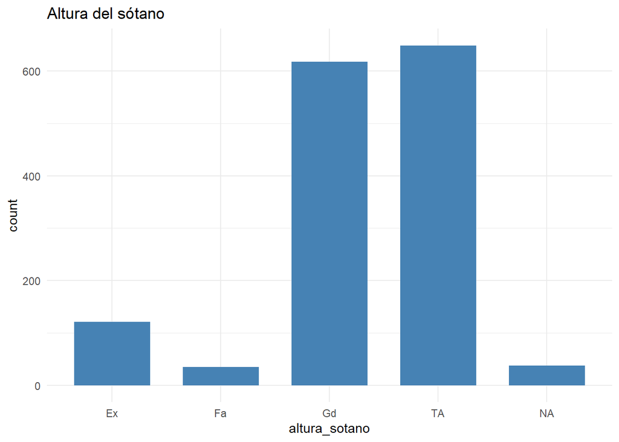

Con esta variable se evalúa la altura del sótado, en donde la mayoría cuenta con una altura típica ded 80 - 89 pulgadas.

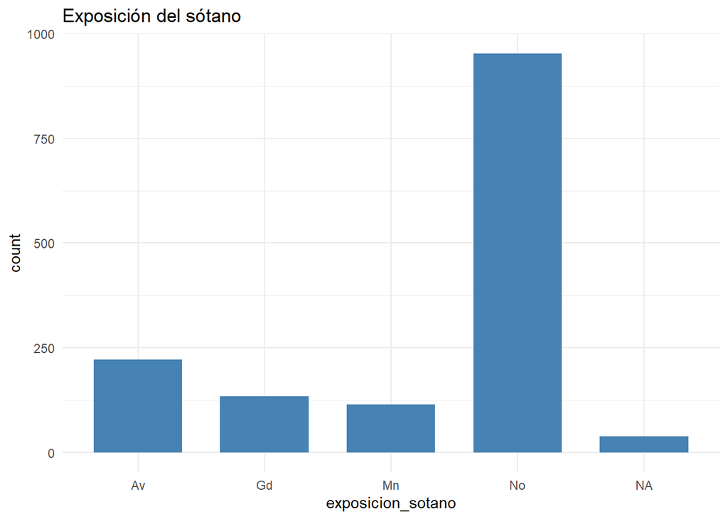

En este caso, se representa los muros del sótano a nivel de jardín o si existe un espacio suficiente para tener una salida directa del sótado al jardín, en donde la mayoría no cuenta con espacio suficiente para tener una puerta directa hacia el jardín.

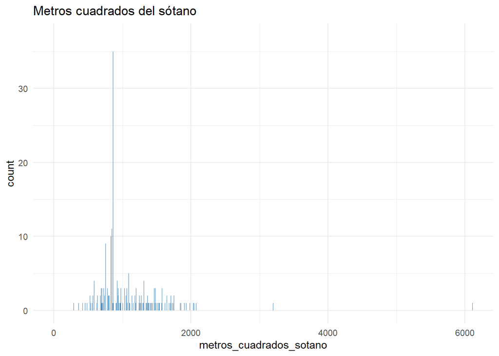

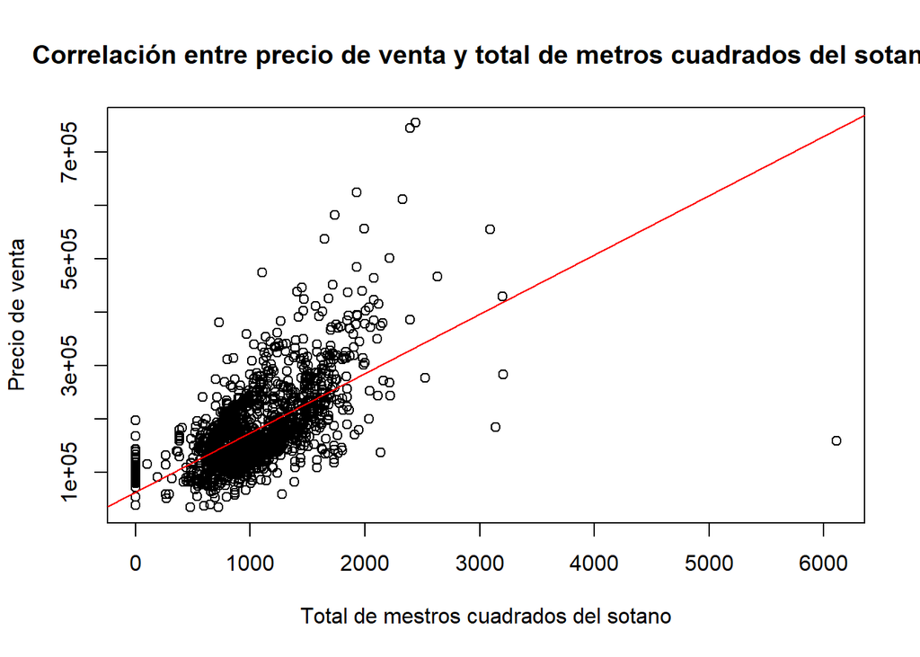

Según lo observado, a pesar que se cuente con lagunos puntos atipicos, sí existe una correlación entre el precio de venta y el total de metros cuadrados del area del sotano.

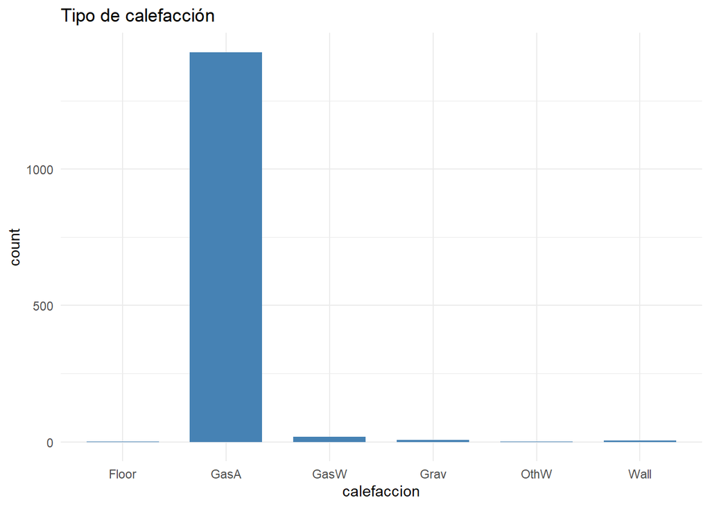

Puede observarse que el tipo de calefacción más común es el horno de aire caliente forzado a gas.

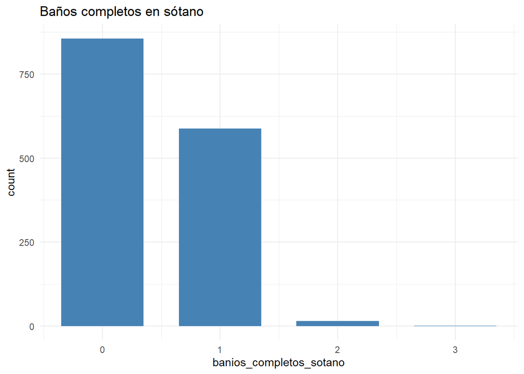

Puede observarse que es más común que no se cuente con baños completos en los sótanos.

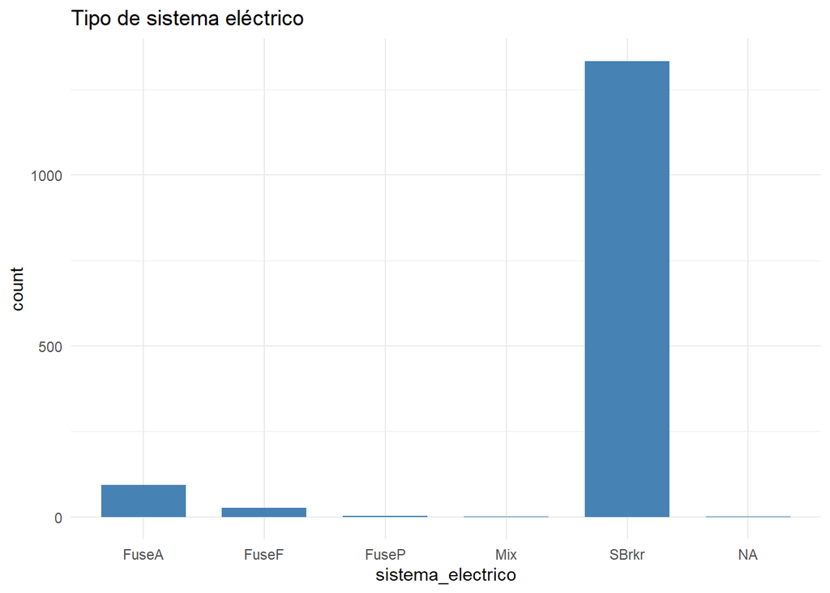

En la mayoría de hogares se cuenta con us sistemaeléctrico de disyuntores estándar y Romex

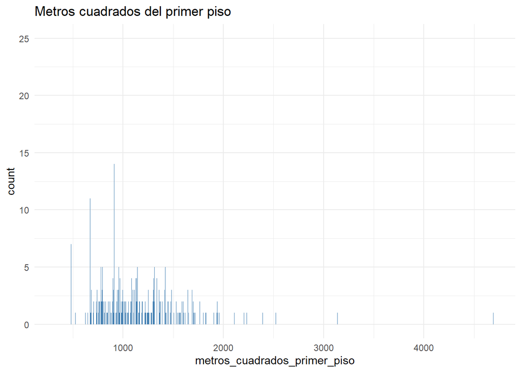

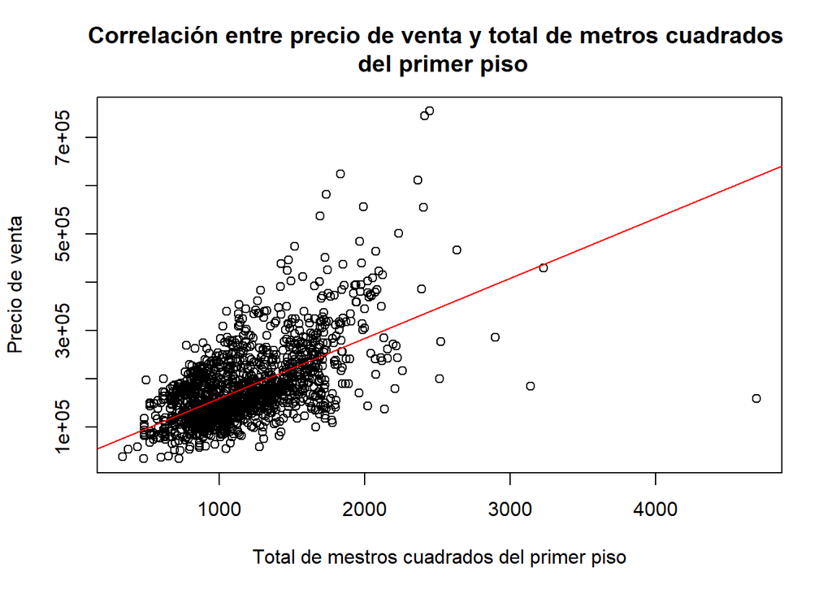

Puede observarse que sí existe correlación entre el total de metros cuadrados del primer piso y el precio de venta.

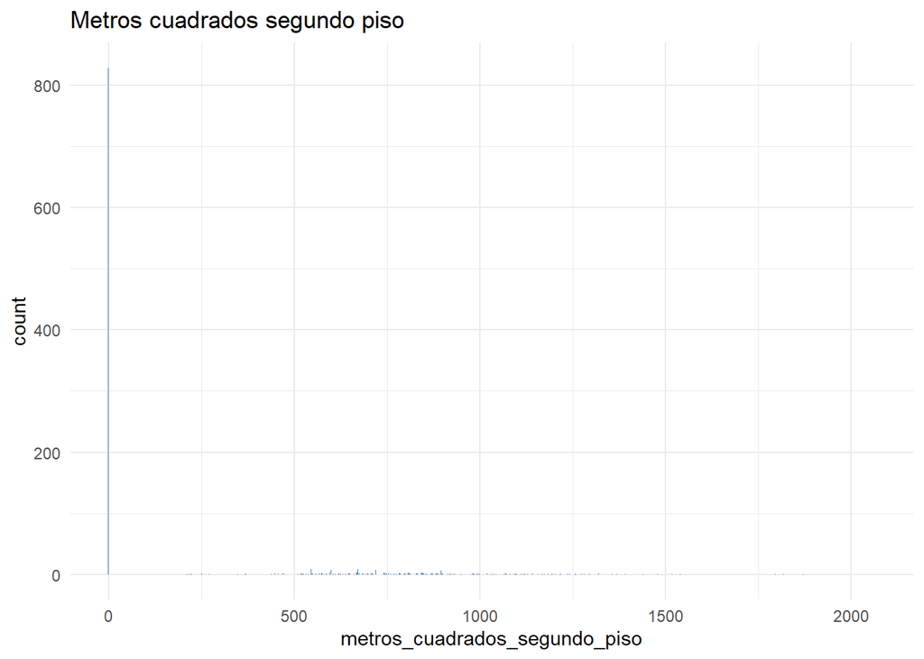

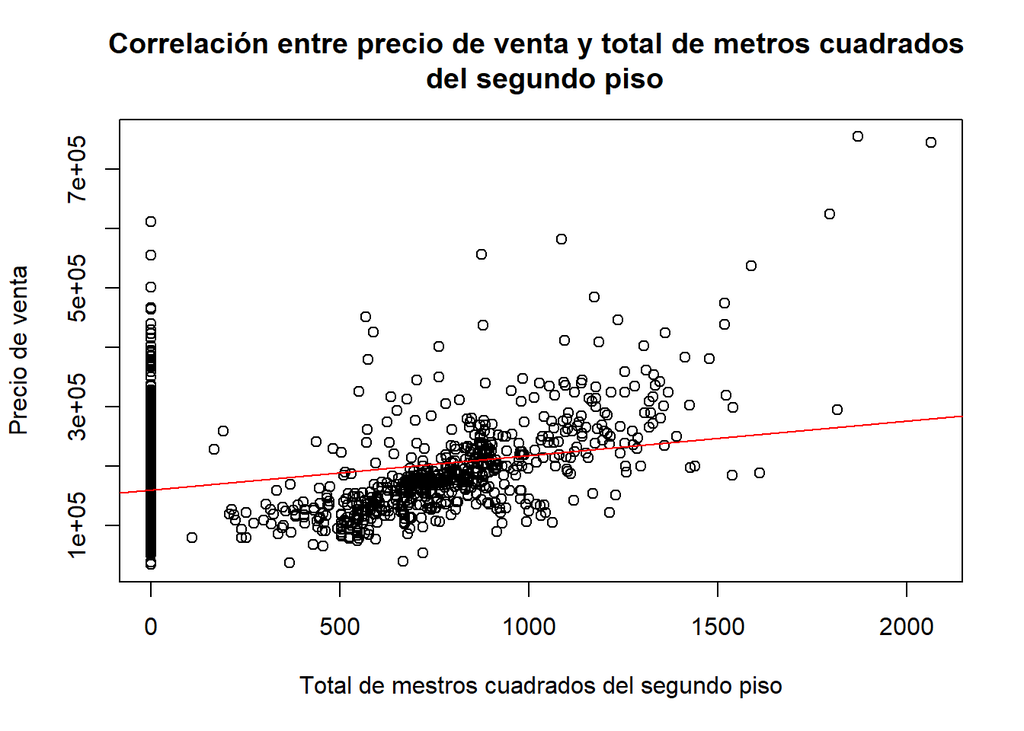

En este caso, los valores que cuentan con 0 metros cuadrados en el segundo piso hacen referencia a las casas que no cuentan con un segundo piso, por lo que, si no se toman en cuenta esos valores, sí existe correlación entre los metros cuadrados del segundo piso y el precio de venta de la casa.

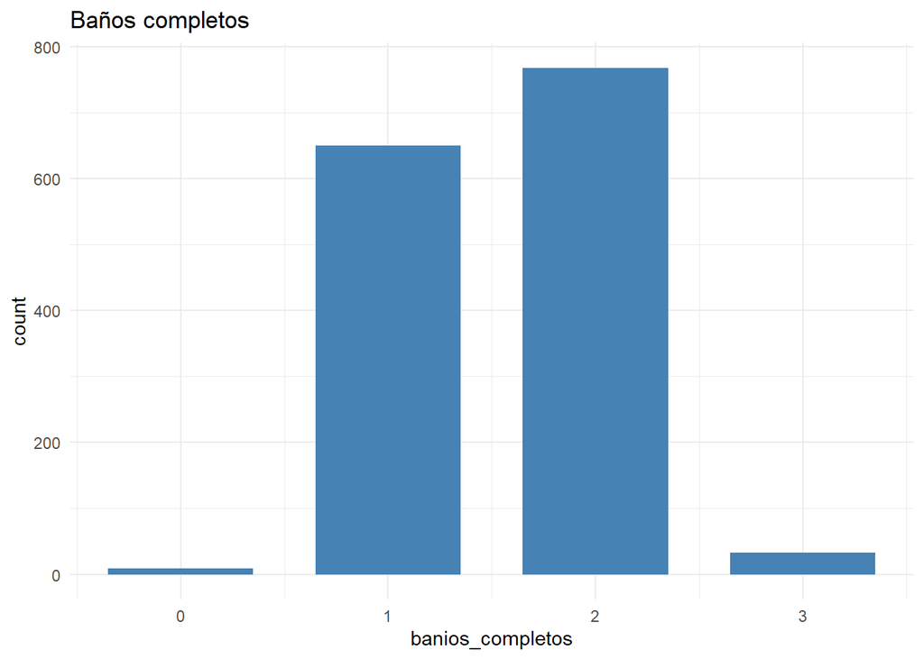

En la mayoría de casas se cuenta con 2 baños completos, sin tomar en cuenta los baños del sótano.

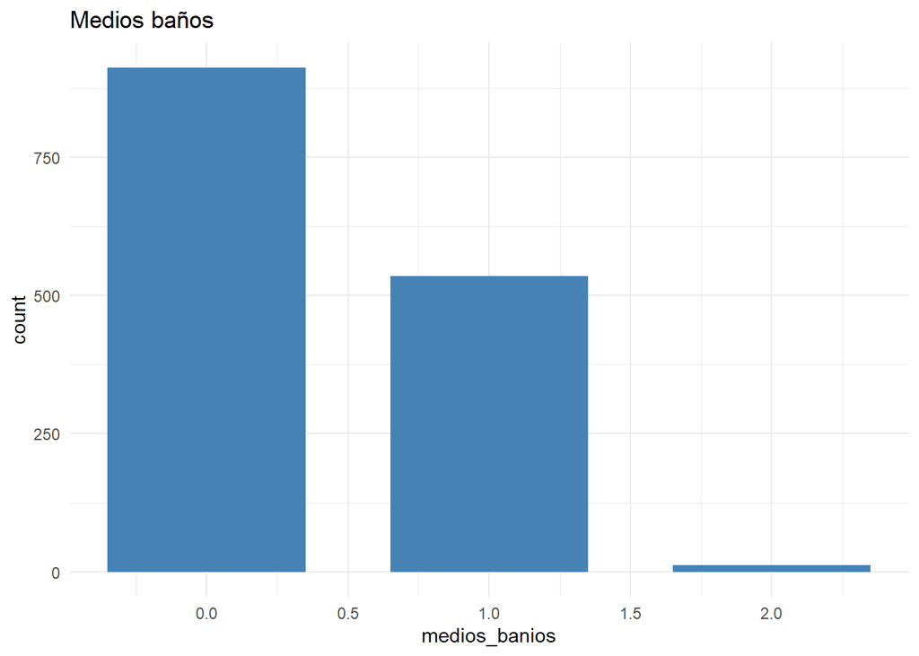

La mayoría de casas no cuenta con medios baños.

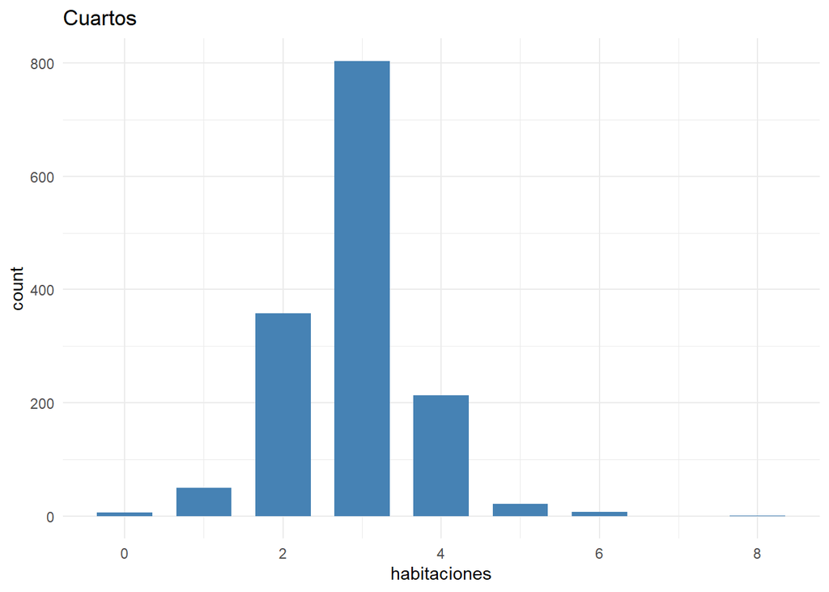

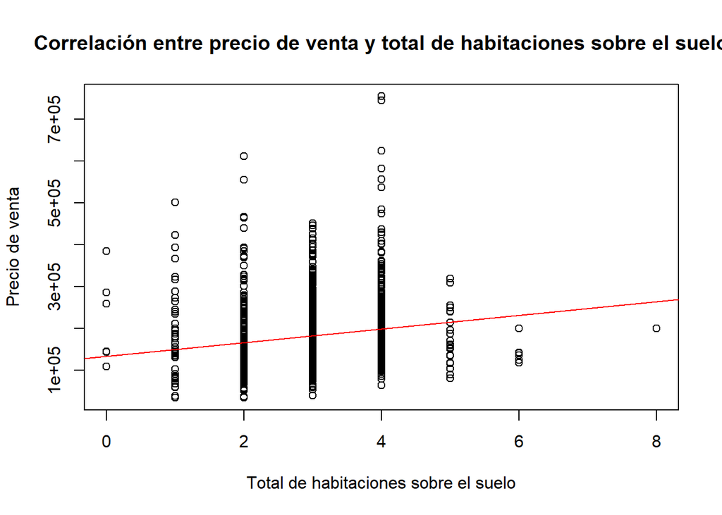

La mayoría de casas cuenta con 3 cuartos sobre el nivel del suelo. Puede observarse también que no existe correlación entre la cantidad de cuartos y el precio de venta, ya que las casas que cuentan con más cuartos se encuentran entre los precios de venta más bajos.

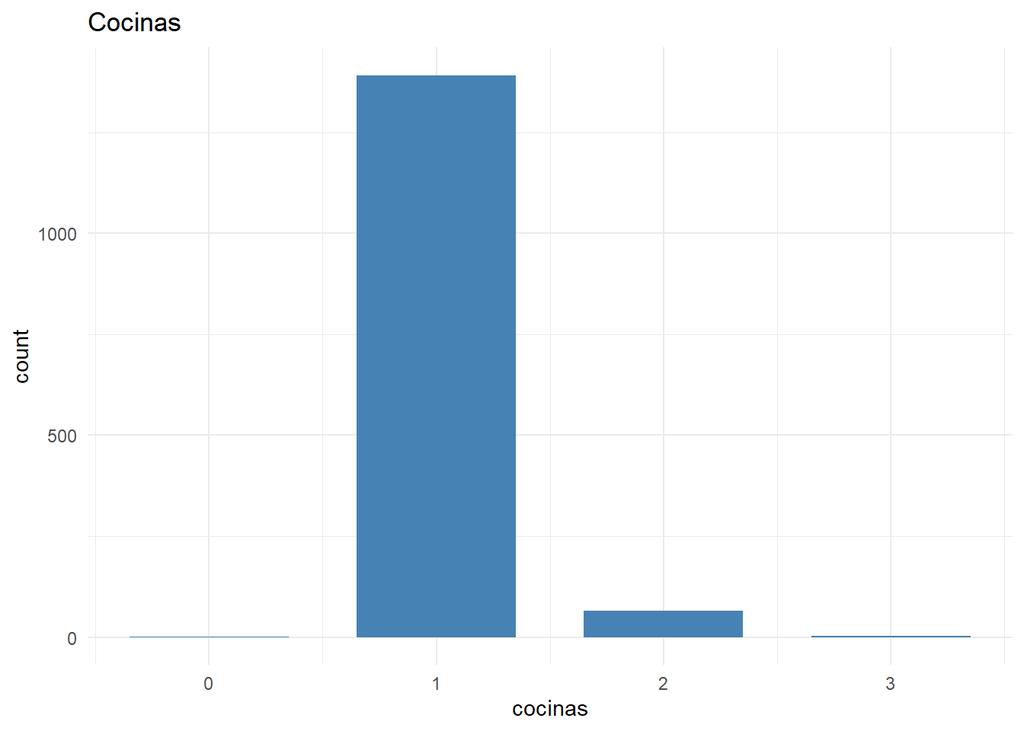

La mayoría de casas cuenta únicamente con una cocina sobre el nivel del suelo.

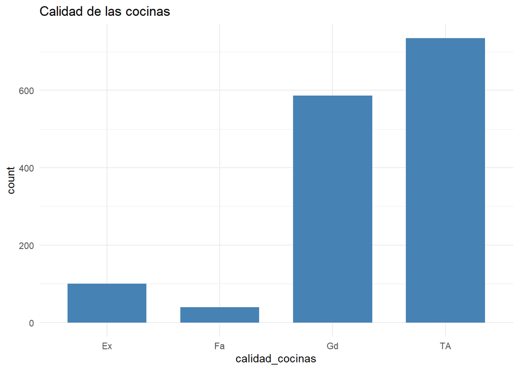

En este gráfico puede observarse que la calidad de las cocinas es típica o promedio.

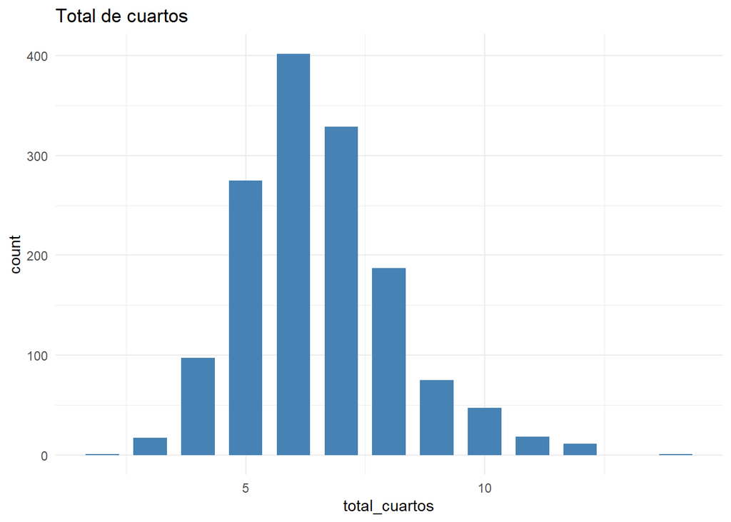

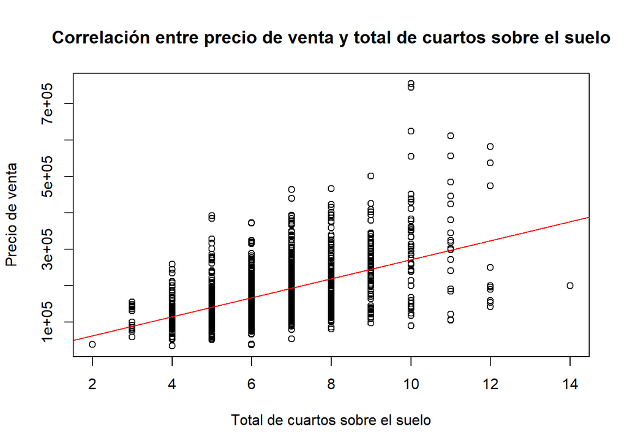

Puede observarse que en total de cuartos, sin tomar en cuenta los baños completos, la mayoría de casas cuenta con 6 cuartos. A su vez, puede observarse que este dato sí tiene correlación con el precio de venta, ya que a medida que va aumentando la cantidad de cuartos, va aumentando el precio de venta.

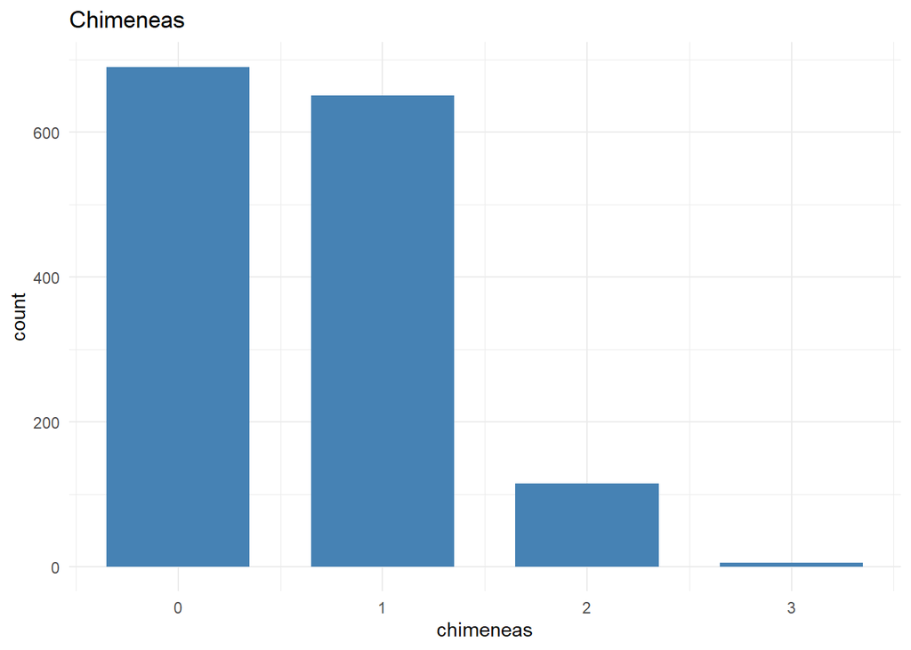

En la mayoría de las casas no se cuenta con chimeneas, sin embargo, es poca la diferencia con la cantidad de casas que cuentan con una chimenea.

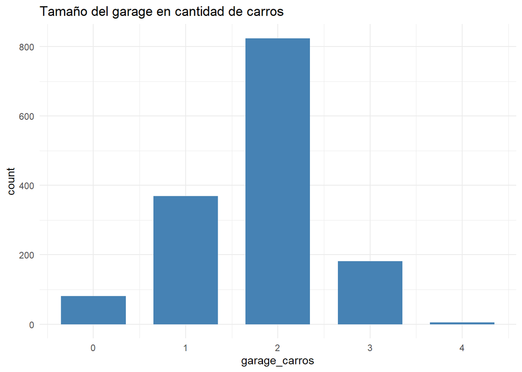

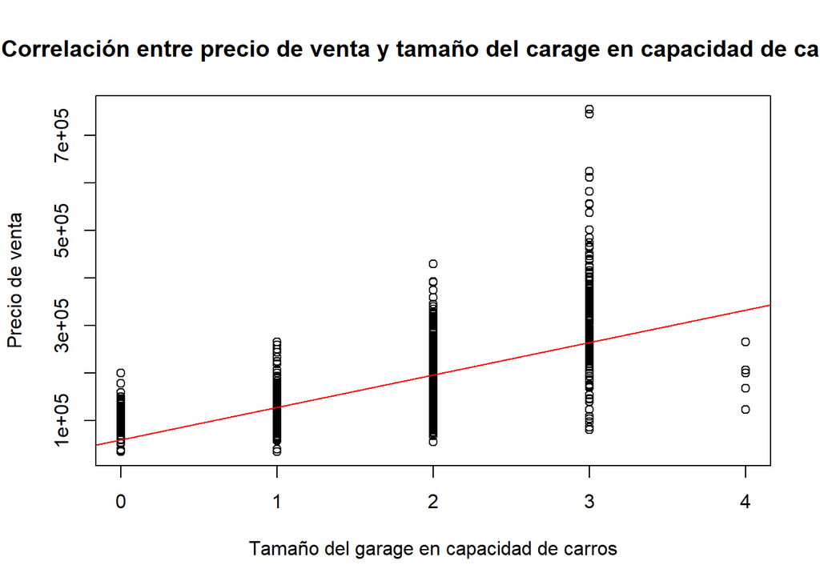

Puede observarse que la mayoría de casas tiene un garage con una capacidad de dos carros, al igual que existe una correlación entre este dato y el precio de venta, ya que a mayor cantidad de carros que entran en un garage, mayor precio de venta.

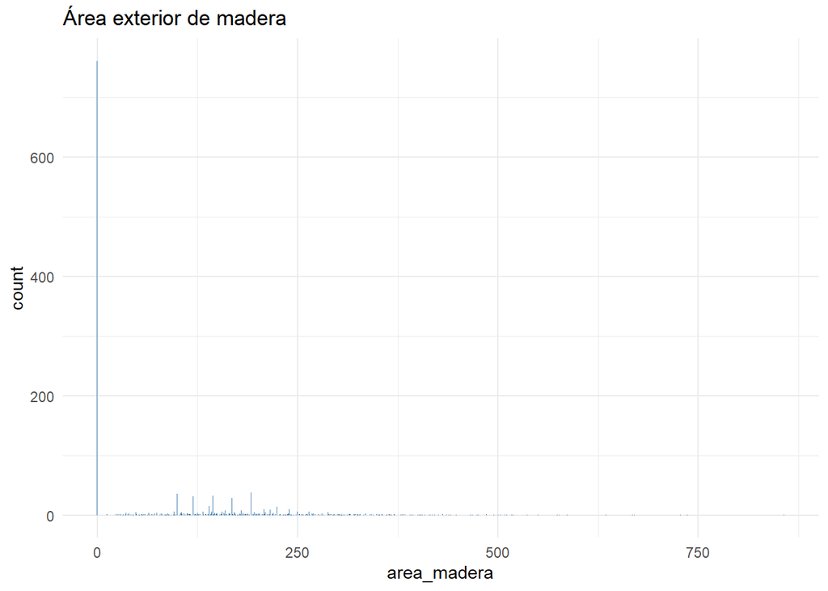

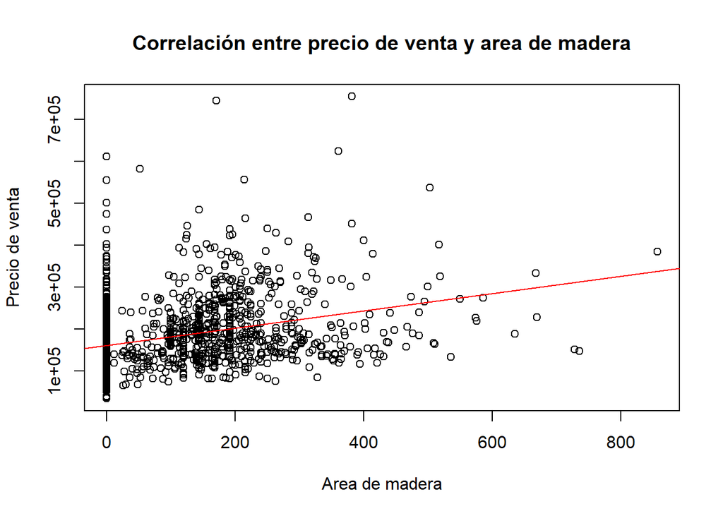

Todos los valores en cero pueden ser interpretados como las casas que no cuentan con un área de madera, luego al observar los demás valores, se considera que existen demasiados valores atípicos por lo que no hay correlación entre el área de madera y el precio de venta.

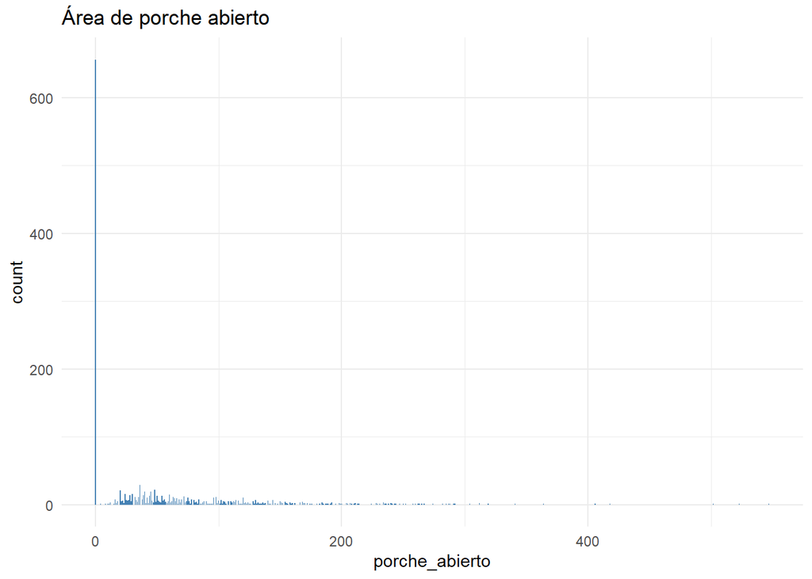

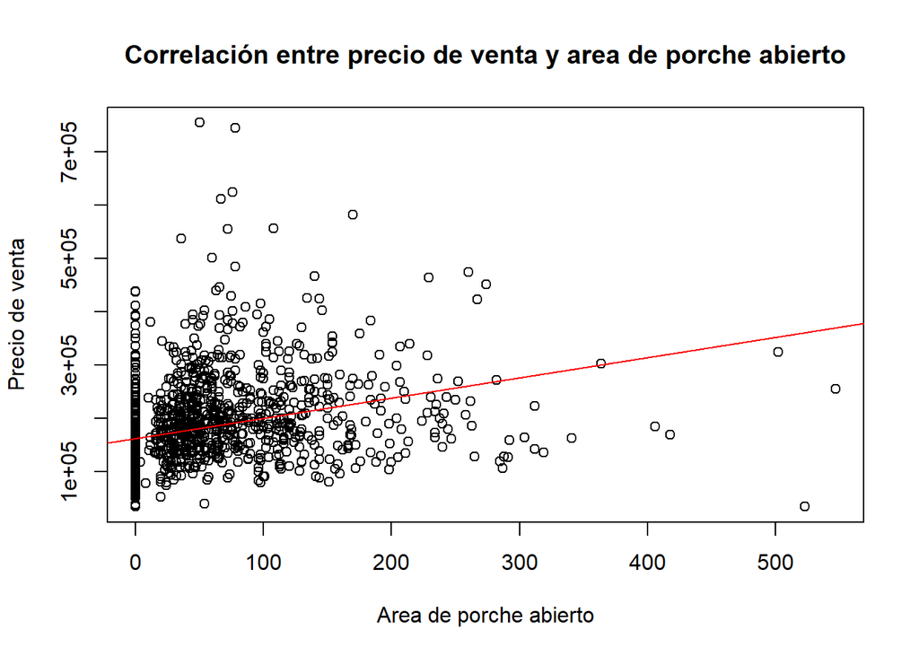

Todos los valores en cero pueden ser interpretados como las casas que no cuentan con área de porche abierto, luego al observar los demás valores, se considera que existen demasiados valores atípicos por lo que no hay correlación entre el área de porche abierto y el precio de venta.

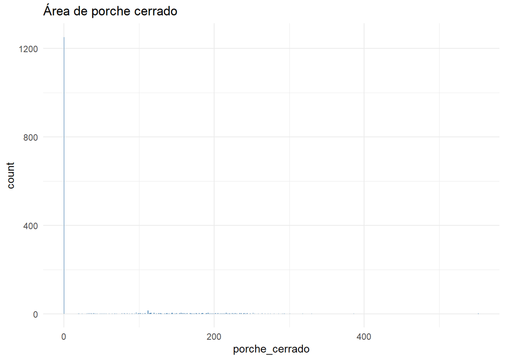

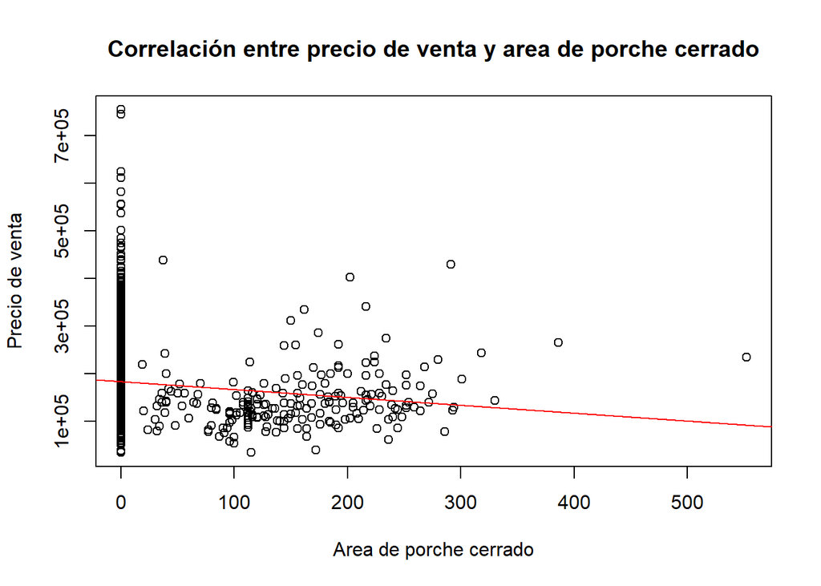

Todos los valores en cero pueden ser interpretados como las casas que no cuentan con área de porche cerrado, luego al observar los demás valores, se considera que existen demasiados valores atípicos por lo que no hay correlación entre el área de porche cerrado y el precio de venta.

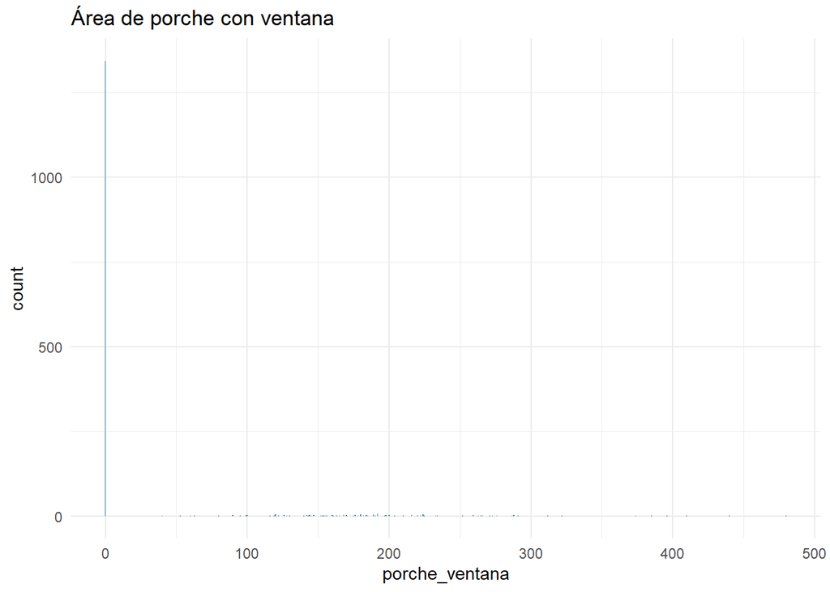

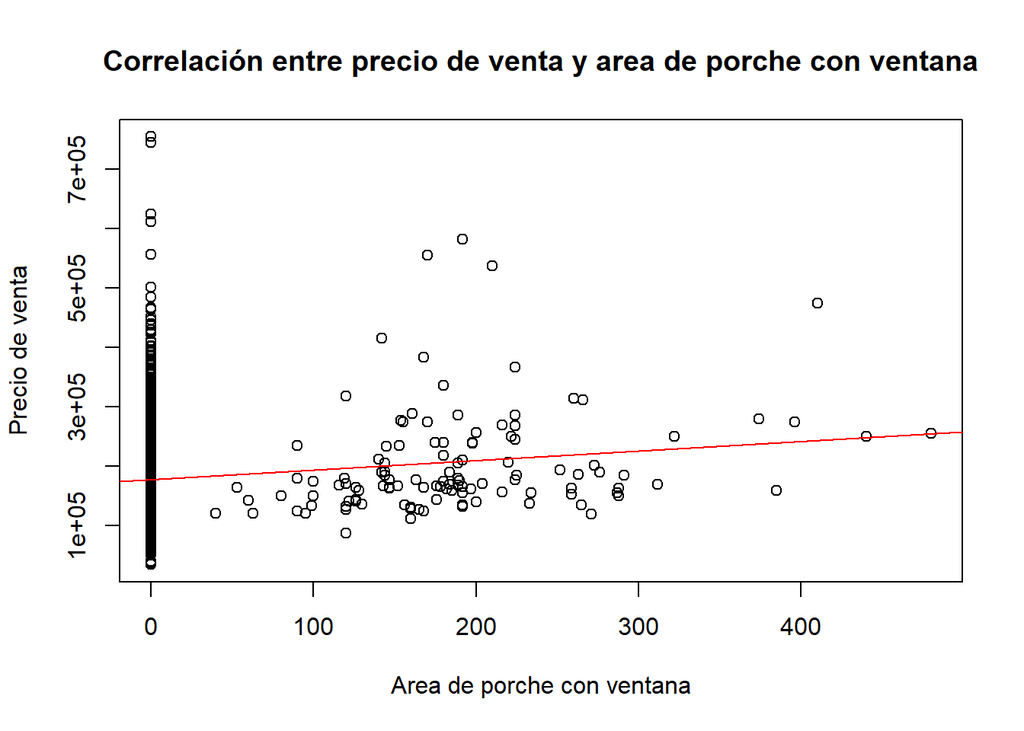

Todos los valores en cero pueden ser interpretados como las casas que no cuentan con área de porche con ventana, luego al observar los demás valores se considera que existen demasiados valores atípicos por lo que no hay correlación entre el área de porche con ventana y el precio de venta.

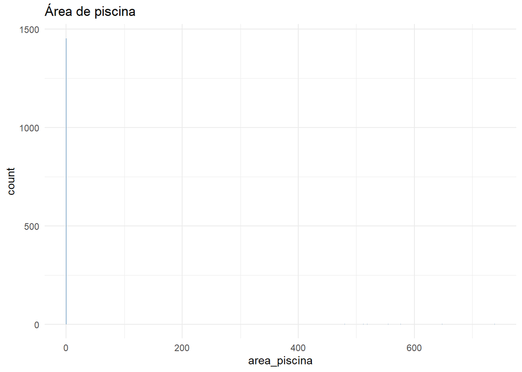

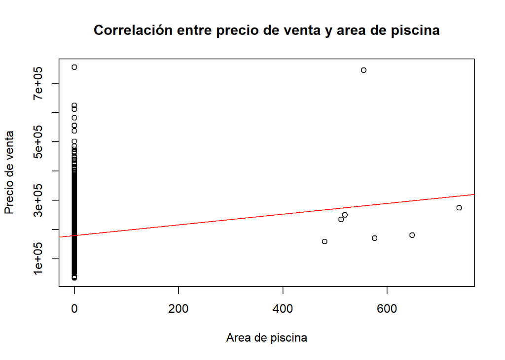

Todos los valores en cero pueden ser interpretados como las casas que no cuentan con área de piscina, luego al observar los demás valores se considera que no existen suficientes datos para determinar que sí existe correlación entre el área de piscina y el precio de venta.

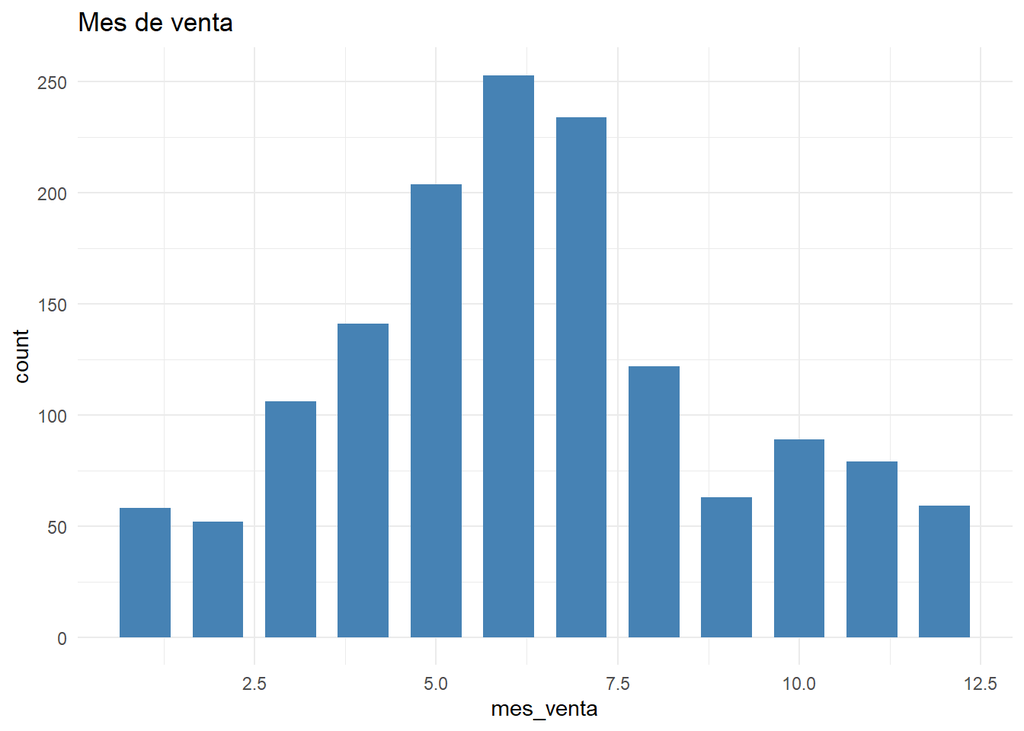

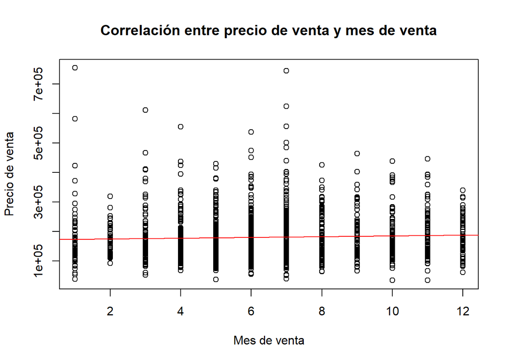

Puede observarse que han habido más ventas durante el mes de junio, sin embargo, no existe correlación entre el mes de venta y el precio de venta.

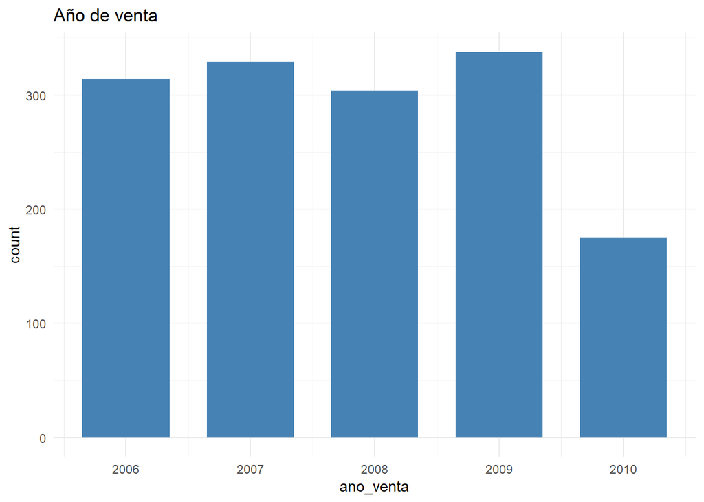

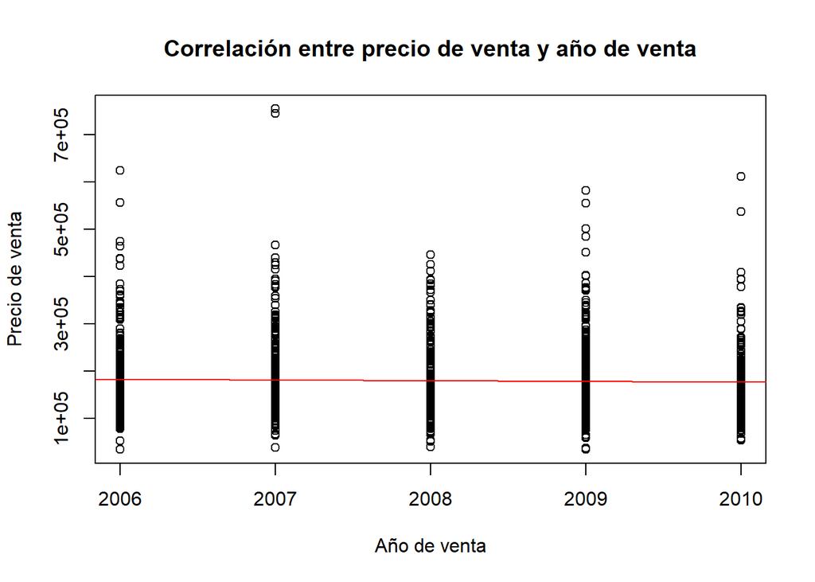

Puede observarse que han habido más ventas durante el 2009, sin embargo, no existe correlación entre el año de venta y el precio de venta.

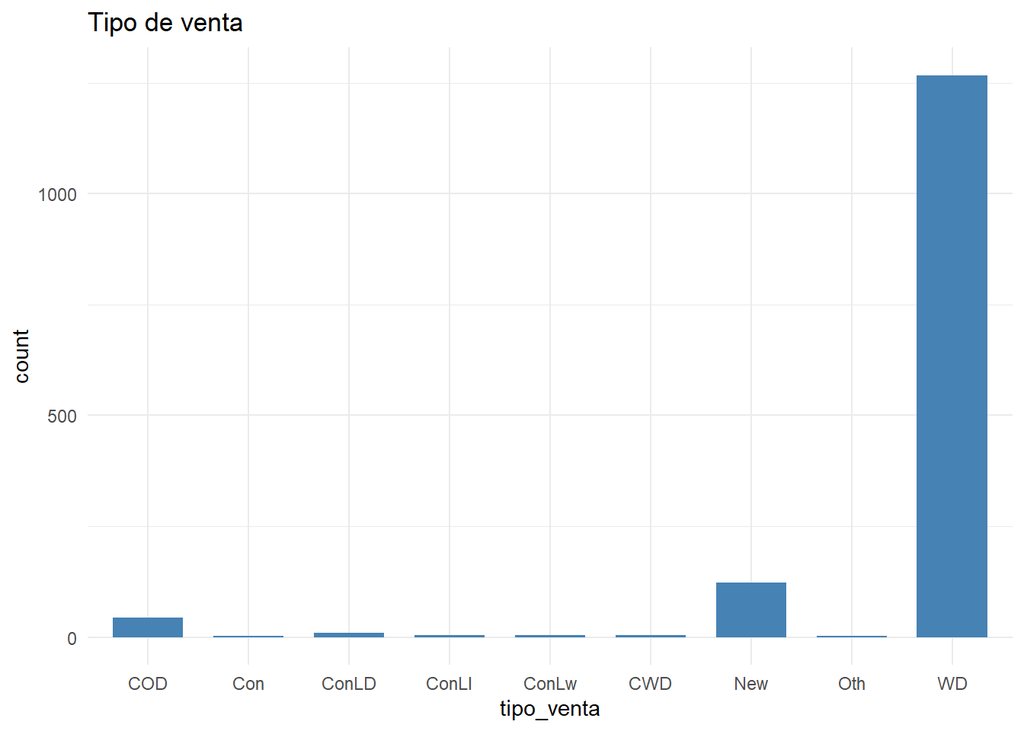

Puede observarse que el tipo de venta más común es el convencional con una escritura de garantía.

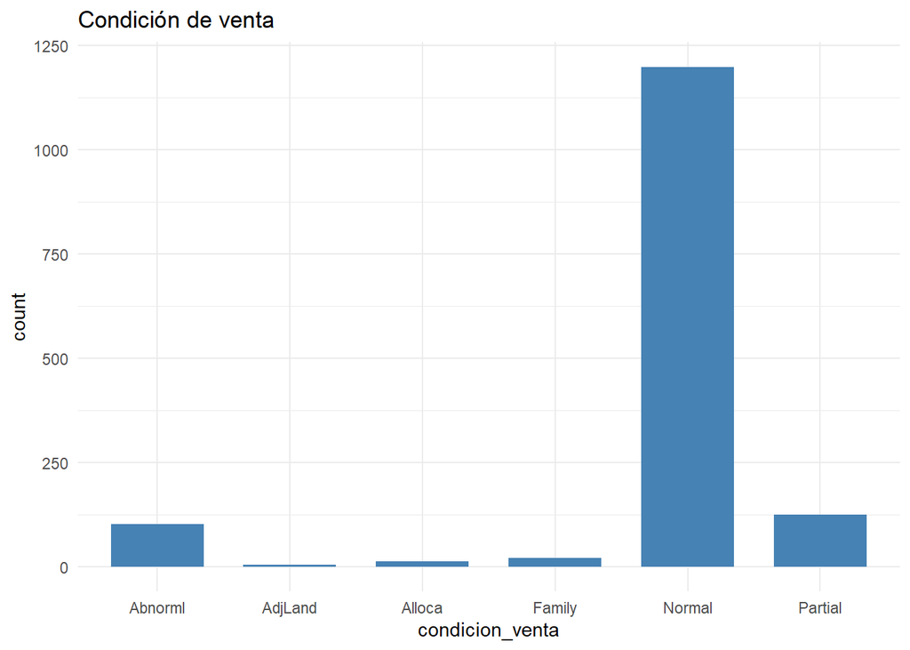

Por último, puede observarse que la condición de venta más común es una venta normal.

## Seccion de clustering

Se trabajará con las siguientes variables que tienen formato int para formas grupos: LotArea, overallQual, overallCond, yearBuilt,bedroomAbvGr, GarageArea, SalePrice Esto debido a que son variables que se pueden clasificar por grupos y los resultados pueden ser interpretados.

```
##     LotArea        OverallQual      OverallCond      YearBuilt
##  Min.   :  1300   Min.   : 1.000   Min.   :1.000   Min.   :1872
##  1st Qu.:  7554   1st Qu.: 5.000   1st Qu.:5.000   1st Qu.:1954
##  Median :  9478   Median : 6.000   Median :5.000   Median :1973
##  Mean   : 10517   Mean   : 6.099   Mean   :5.575   Mean   :1971
##  3rd Qu.: 11602   3rd Qu.: 7.000   3rd Qu.:6.000   3rd Qu.:2000
##  Max.   :215245   Max.   :10.000   Max.   :9.000   Max.   :2010
##   BedroomAbvGr     GarageArea       SalePrice
##  Min.   :0.000   Min.   :   0.0   Min.   : 34900
##  1st Qu.:2.000   1st Qu.: 334.5   1st Qu.:129975
##  Median :3.000   Median : 480.0   Median :163000
##  Mean   :2.866   Mean   : 473.0   Mean   :180921
##  3rd Qu.:3.000   3rd Qu.: 576.0   3rd Qu.:214000
##  Max.   :8.000   Max.   :1418.0   Max.   :755000
```

Para saber la mejor cantidad de clusters a utilizar, se hará lo siguiente:

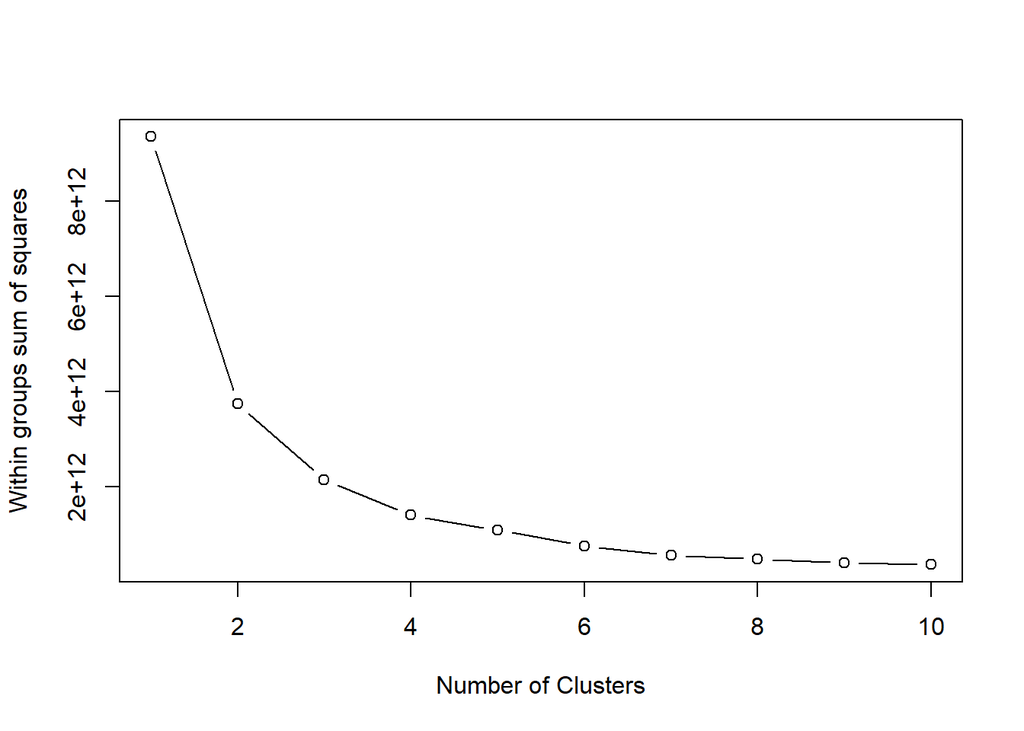

En base a esto, se determinó que el número ideal de clusters es 3

### Agrupamiento por medio de k-means

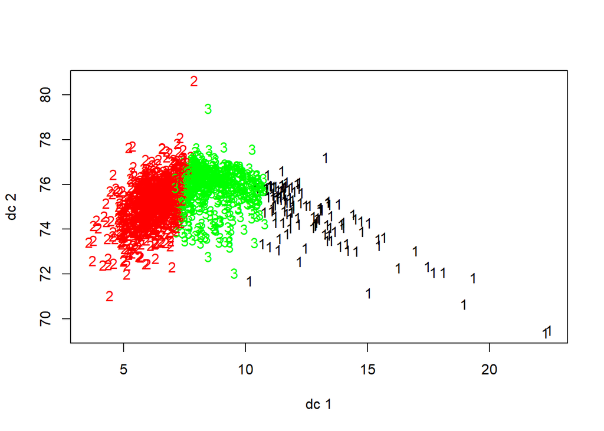

Se puede observar cómo es que se han dividido los tres grupos, siendo el primero el de color negro, el segundo el de color rojo y el tercero el de color verde. Los grupos rojo y verde se encuentran altamente aglomerados, mientras que el grupo negro agrupa los datos más dispersos

### Agrupamiento por medio de clustering jerárquico

```
##
## Call:
## hclust(d = dist(datos[, 1:7]))
##
## Cluster method   : complete
## Distance         : euclidean
## Number of objects: 1460
```

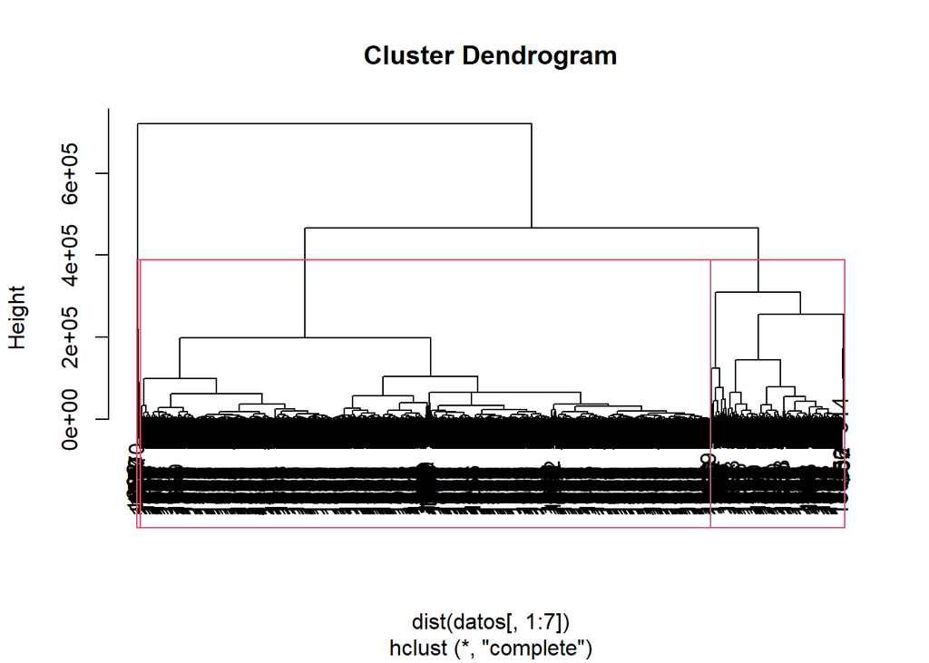

### Calidad del agrupamiento

#### K-means

```
## [1] 0.5487144
```

#### Cluster jerárquico

```
## [1] 0.6258748
```

Según los valores obtenidos, el que cuenta con la mayor silueta es el cluster jerárquico con un valor de 0.625, seguido de cerca de K means

```
##     LotArea       OverallQual      OverallCond      YearBuilt
##  Min.   : 1300   Min.   : 1.000   Min.   :1.000   Min.   :1872
##  1st Qu.: 7200   1st Qu.: 5.000   1st Qu.:5.000   1st Qu.:1949
##  Median : 8960   Median : 6.000   Median :5.000   Median :1967
##  Mean   : 9299   Mean   : 5.678   Mean   :5.614   Mean   :1966
##  3rd Qu.:10792   3rd Qu.: 6.000   3rd Qu.:6.000   3rd Qu.:1994
##  Max.   :63887   Max.   :10.000   Max.   :9.000   Max.   :2009
##   BedroomAbvGr     GarageArea       SalePrice          grupo          gruposHC
##  Min.   :0.000   Min.   :   0.0   Min.   : 34900   Min.   :2.000   Min.   :1
##  1st Qu.:2.000   1st Qu.: 297.0   1st Qu.:124000   1st Qu.:2.000   1st Qu.:1
##  Median :3.000   Median : 440.0   Median :147000   Median :2.000   Median :1
##  Mean   :2.826   Mean   : 419.9   Mean   :150516   Mean   :2.314   Mean   :1
##  3rd Qu.:3.000   3rd Qu.: 528.0   3rd Qu.:179783   3rd Qu.:3.000   3rd Qu.:1
##  Max.   :8.000   Max.   :1418.0   Max.   :232600   Max.   :3.000   Max.   :1
```

```
##     LotArea        OverallQual      OverallCond      YearBuilt
##  Min.   :  3196   Min.   : 4.000   Min.   :2.000   Min.   :1880
##  1st Qu.: 10120   1st Qu.: 7.000   1st Qu.:5.000   1st Qu.:1992
##  Median : 11839   Median : 8.000   Median :5.000   Median :2003
##  Mean   : 15319   Mean   : 7.791   Mean   :5.422   Mean   :1993
##  3rd Qu.: 14230   3rd Qu.: 8.000   3rd Qu.:5.000   3rd Qu.:2006
##  Max.   :215245   Max.   :10.000   Max.   :9.000   Max.   :2010
##   BedroomAbvGr     GarageArea       SalePrice          grupo          gruposHC
##  Min.   :0.000   Min.   : 180.0   Min.   :228950   Min.   :1.000   Min.   :2
##  1st Qu.:3.000   1st Qu.: 552.0   1st Qu.:251000   1st Qu.:1.000   1st Qu.:2
##  Median :3.000   Median : 683.0   Median :278000   Median :3.000   Median :2
##  Mean   :3.022   Mean   : 688.3   Mean   :297184   Mean   :2.199   Mean   :2
##  3rd Qu.:4.000   3rd Qu.: 834.0   3rd Qu.:325000   3rd Qu.:3.000   3rd Qu.:2
##  Max.   :5.000   Max.   :1390.0   Max.   :501837   Max.   :3.000   Max.   :2
```

```
##     LotArea       OverallQual      OverallCond      YearBuilt     BedroomAbvGr
##  Min.   :12919   Min.   : 8.000   Min.   :5.000   Min.   :1994   Min.   :2.0
##  1st Qu.:15046   1st Qu.: 9.000   1st Qu.:5.000   1st Qu.:1996   1st Qu.:3.5
##  Median :15840   Median : 9.500   Median :5.000   Median :2004   Median :4.0
##  Mean   :23090   Mean   : 9.375   Mean   :5.125   Mean   :2002   Mean   :3.5
##  3rd Qu.:25091   3rd Qu.:10.000   3rd Qu.:5.000   3rd Qu.:2008   3rd Qu.:4.0
##  Max.   :53504   Max.   :10.000   Max.   :6.000   Max.   :2009   Max.   :4.0
##    GarageArea       SalePrice          grupo      gruposHC
##  Min.   : 672.0   Min.   :538000   Min.   :1   Min.   :3
##  1st Qu.: 784.2   1st Qu.:556186   1st Qu.:1   1st Qu.:3
##  Median : 816.5   Median :597295   Median :1   Median :3
##  Mean   : 815.1   Mean   :621146   Mean   :1   Mean   :3
##  3rd Qu.: 834.2   3rd Qu.:655000   3rd Qu.:1   3rd Qu.:3
##  Max.   :1020.0   Max.   :755000   Max.   :1   Max.   :3
```

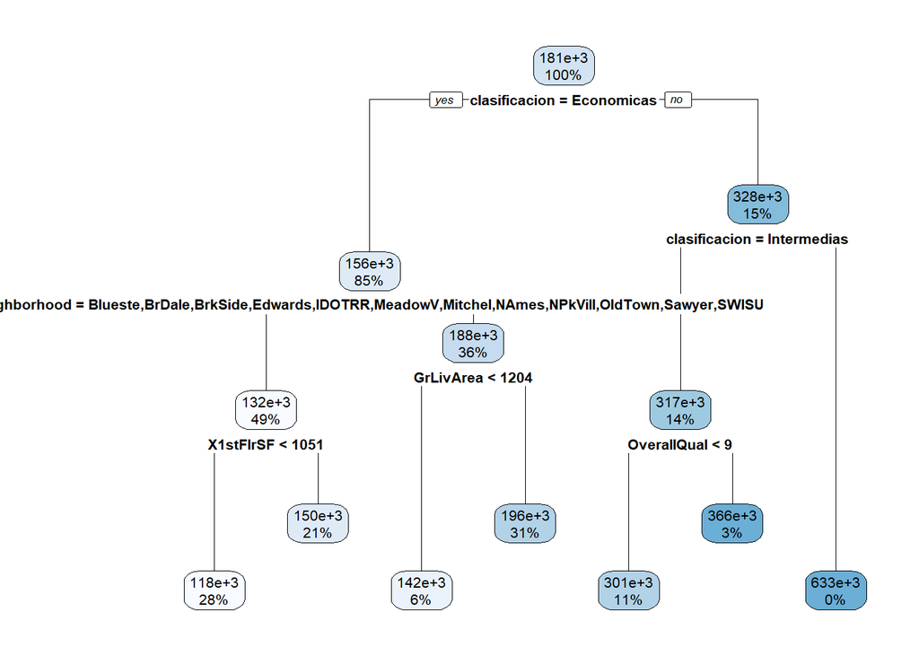

Árbol de regresión para predecir el precio de las viviendas utilizando el conjunto de entrenamiento.

[output not shown]

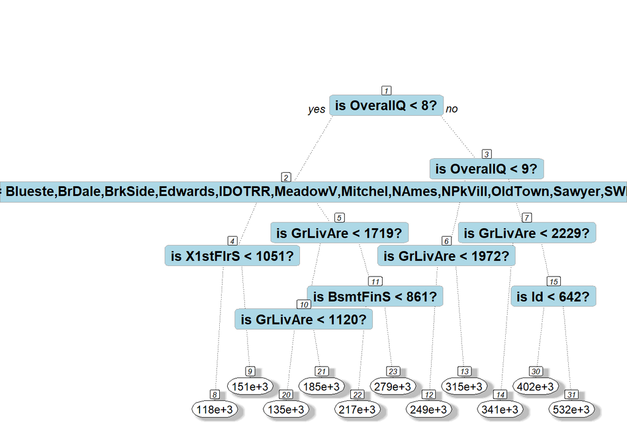

Uso de PREDICT: Entre más cerca estén de Y , los observados se puede decir que el modelo es mejor. A continuación la correlación:eficiencia del algoritmo para clasificar y predecir, en dependencia de las características de la variable respuesta.

```
## [1] 0.8748791
```

A continuación un diagrama de dispersión donde se muestra la predicción de los precios de las viviendas

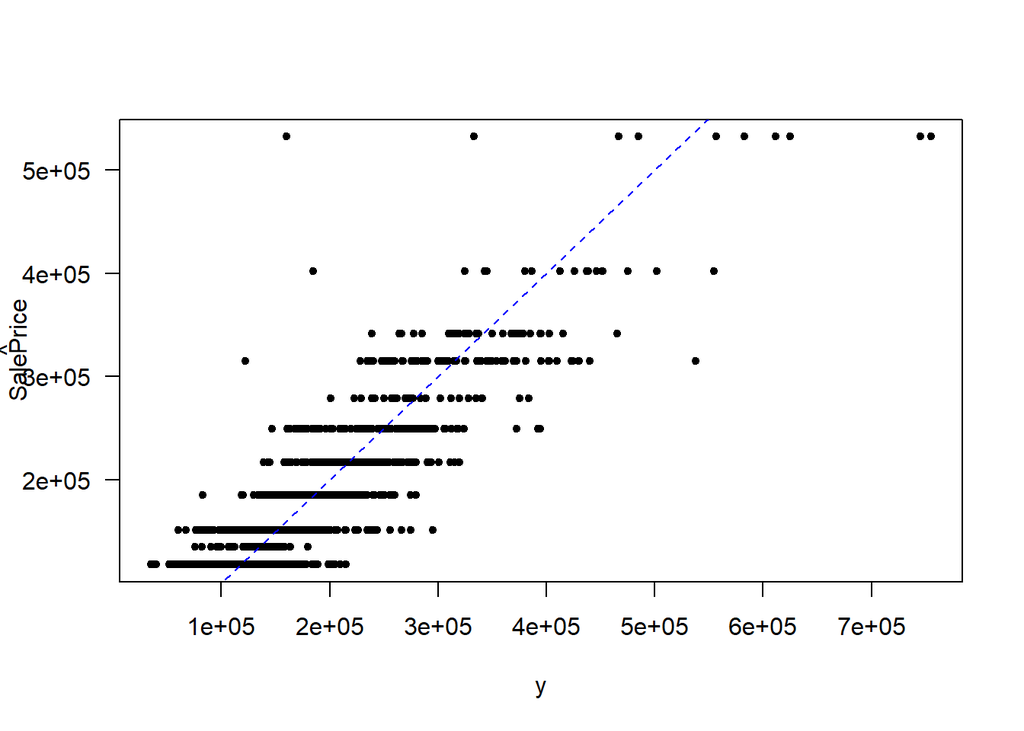

```
## [1] 1168 2000
```

```
##   positive negative predicted_positive predicted_negative
## 1      299     8533                 85               8747
```

La impureza de Gini es la probabilidad de cada elemento siendo elegido multiplicado por la probabilidad de un error en la categorización de ese elemento. Alcanza su mínimo (cero) cuando todos los casos del nodo corresponden a una sola categoría de destino

```
##
## Call:
##  randomForest(formula = Species ~ ., data = iris, importance = TRUE,      proximity = TRUE)
##                Type of random forest: classification
##                      Number of trees: 500
## No. of variables tried at each split: 2
##
##         OOB estimate of  error rate: 4.67%
## Confusion matrix:
##            setosa versicolor virginica class.error
## setosa         50          0         0        0.00
## versicolor      0         47         3        0.06
## virginica       0          4        46        0.08
```

```
##              setosa versicolor virginica MeanDecreaseAccuracy MeanDecreaseGini
## Sepal.Length   5.88       5.87      9.21                10.62             9.37
## Sepal.Width    5.23       0.31      4.71                 4.94             2.45
## Petal.Length  21.60      31.41     27.71                32.39            42.13
## Petal.Width   22.96      33.74     32.07                33.85            45.28
```

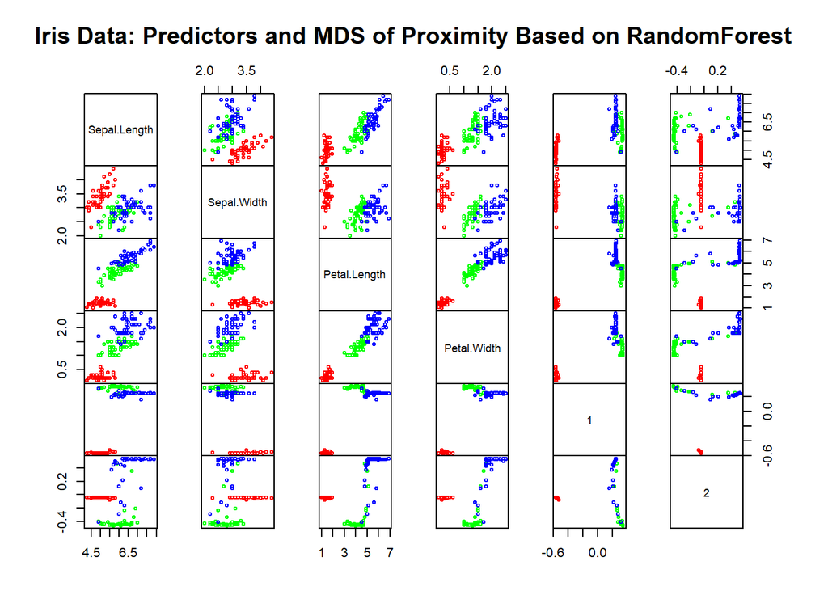

```
## [1] 0.7373483 0.7989356
```

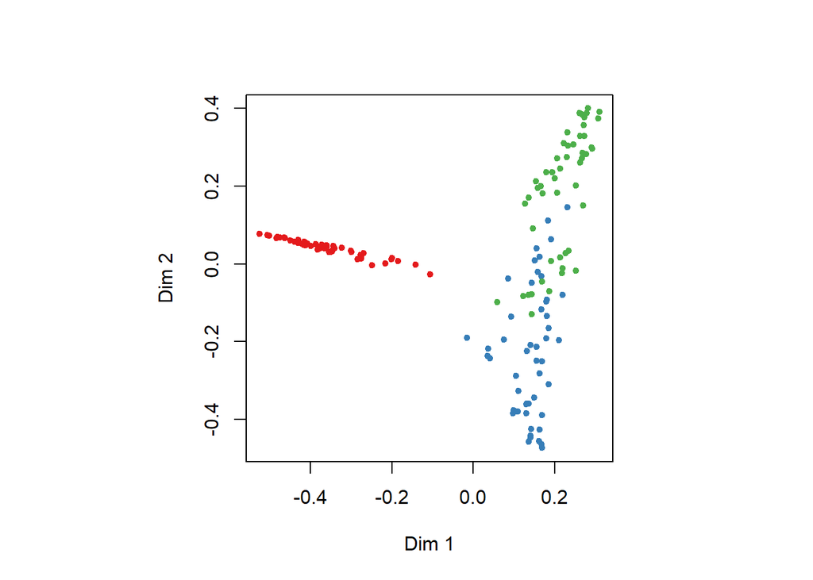

```
##
## Call:
##  randomForest(x = iris[1:4], y = iris$Species, sampsize = c(20,      30, 20))
##                Type of random forest: classification
##                      Number of trees: 500
## No. of variables tried at each split: 2
##
##         OOB estimate of  error rate: 4.67%
## Confusion matrix:
##            setosa versicolor virginica class.error
## setosa         50          0         0        0.00
## versicolor      0         47         3        0.06
## virginica       0          4        46        0.08
```

```
##
## Call:
##  randomForest(formula = Ozone ~ ., data = airquality, mtry = 3,      importance = TRUE, na.action = na.omit)
##                Type of random forest: regression
##                      Number of trees: 500
## No. of variables tried at each split: 3
##
##           Mean of squared residuals: 302.2117
##                     % Var explained: 72.46
```

```
##         %IncMSE IncNodePurity
## Solar.R    9.76      10741.33
## Wind      22.15      44234.96
## Temp      43.85      53787.56
## Month      2.59       1692.48
## Day        0.93       6606.39
```

```
##
## Call:
##  randomForest(x = x, y = y)
##                Type of random forest: classification
##                      Number of trees: 500
## No. of variables tried at each split: 2
##
##         OOB estimate of  error rate: 52%
## Confusion matrix:
##    1  2 class.error
## 1 25 25        0.50
## 2 27 23        0.54
```

[output not shown]

```
##
## Call:
##  randomForest(formula = sqrt(Fertility) ~ . - Catholic + I(Catholic <      50), data = swiss)
##                Type of random forest: regression
##                      Number of trees: 500
## No. of variables tried at each split: 1
##
##           Mean of squared residuals: 0.3277816
##                     % Var explained: 44.34
```

[output not shown]

```
##
## Call:
##  randomForest(x = x[-3], y = x[[3]], ntree = 10)
##                Type of random forest: regression
##                      Number of trees: 10
## No. of variables tried at each split: 1
##
##           Mean of squared residuals: 1.599315
##                     % Var explained: -44.33
```

[output not shown]

[output not shown]